# **Milestone 2**

by Sulian Thual - for MIT ASDP October 2021

We build a computer vision model for malaria detection. In this notebook we work on Milestone 2, which consists in building the model and experimenting on its characteristics (architecture, hyperparameters, etc) for improved performances.

Note: for best performances, use Google Collab. Select Edit/Notebook Settings/GPU.

# **Part I: Base Functions**

### **Mounting the Drive**

```python
#Mounting the drive
from google.colab import drive
drive.mount('/content/drive')
```

### **Loading libraries**

```python
#Importing libraries required to load the data

import zipfile
import os
from PIL import Image
import numpy as np
import pandas as pd
import matplotlib.pyplot as plt
import seaborn as sns

from sklearn.model_selection import train_test_split
from sklearn.preprocessing import MinMaxScaler

import tensorflow as tf
from tensorflow.keras.models import Sequential
from tensorflow.keras.layers import Dense, Conv2D, MaxPool2D, BatchNormalization, Dropout, Flatten, LeakyReLU, GlobalAvgPool2D
from tensorflow.keras.utils import to_categorical
from tensorflow.keras import optimizers

#to ignore warnings
import warnings
warnings.filterwarnings('ignore')

# Remove the limit from the number of displayed columns and rows. It helps to see the entire dataframe while printing it
pd.set_option("display.max_columns", None)
pd.set_option("display.max_rows", 200)
```

### **Let us load the data**

**Note:**

- You must download the dataset from the link provided on Olympus and upload the same on your Google drive before executing the code in the next cell.
- In case of any error, please make sure that the path of the file is correct as the path may be different for you.

```python
#Storing the path of the data file from the Google drive
path = '/content/drive/MyDrive/Data/cell_images.zip'

#The data is provided as a zip file so we need to extract the files from the zip file
with zipfile.ZipFile(path, 'r') as zip_ref:
    zip_ref.extractall()
```

The extracted folder has different folders for train and test data which further contains the different sizes of images for parasitized and uninfected cells within the respective folder name.

The size of all images must be the same and should be converted to 4D arrays so that they can be used as an input for the convolutional neural network. Also, we need to create the labels for both types of images to be able to train and test the model.

Let's do the same for the training data first and then we will use the same code for the test data as well.

```python
#Storing the path of the extracted "train" folder
train_dir = '/content/cell_images/train'

#Size of image so that each image has the same size
SIZE = 64

#Empty list to store the training images after they are converted to NumPy arrays
train_images = []

#Empty list to store the training labels (0 - uninfected, 1 - parasitized)
train_labels = []
```

```python
#We will run the same code for "parasitized" as well as "uninfected" folders within the "train" folder
for folder_name in ['/parasitized/', '/uninfected/']:

    #Path of the folder
    images_path = os.listdir(train_dir + folder_name)

    for i, image_name in enumerate(images_path):
        try:
            #Opening each image using the path of that image
            image = Image.open(train_dir + folder_name + image_name)

            #Resizing each image to (224,224)
            image = image.resize((SIZE, SIZE))

            #Converting images to arrays and appending that array to the empty list defined above
            train_images.append(np.array(image))

            #Creating labels for parasitized and uninfected images
            if folder_name=='/parasitized/':
                train_labels.append(1)
            else:
                train_labels.append(0)
        except Exception:
            pass

#Converting lists to arrays
train_images = np.array(train_images)
train_labels = np.array(train_labels)
```

```python
#Storing the path of the extracted "test" folder
test_dir = '/content/cell_images/test'

#Size of image so that each image has the same size (it must be same as the train image size)
SIZE = 64

#Empty list to store the testing images after they are converted to NumPy arrays
test_images = []

#Empty list to store the testing labels (0 - uninfected, 1 - parasitized)
test_labels = []
```

```python
#We will run the same code for "parasitized" as well as "uninfected" folders within the "test" folder
for folder_name in ['/parasitized/', '/uninfected/']:

    #Path of the folder
    images_path = os.listdir(test_dir + folder_name)

    for i, image_name in enumerate(images_path):
        try:
            #Opening each image using the path of that image
            image = Image.open(test_dir + folder_name + image_name)

            #Resizing each image to (128,128)
            image = image.resize((SIZE, SIZE))

            #Converting images to arrays and appending that array to the empty list defined above
            test_images.append(np.array(image))

            #Creating labels for parasitized and uninfected images
            if folder_name=='/parasitized/':
                test_labels.append(1)
            else:
                test_labels.append(0)
        except Exception:
            pass

#Converting lists to arrays
test_images = np.array(test_images)
test_labels = np.array(test_labels)
```

### **Normalize the images**

```python
# try to normalize the train and test images by dividing it by 255 and convert them to float32 using astype function
train_images = (train_images/255).astype('float32')
test_images = (test_images/255).astype('float32')
```

As we have done our preprocessing required and performed some EDA to gain some insights in our Milestone-1 so now we will try to build our model and try evaluating its performance.

### **One Hot Encoding on the train and test labels**

```python
# Encoding Train Labels
train_labels=to_categorical(train_labels,2)
# Similarly let us try to encode test labels
test_labels=to_categorical(test_labels,2)
```

#### **Importing the required libraries**

```python
#Clearing backend
from tensorflow.keras import backend
from tensorflow.keras.utils import to_categorical
from tensorflow.keras.models import Sequential
from tensorflow.keras.layers import Conv2D,MaxPooling2D,Dense,Flatten,Dropout
from tensorflow.keras.callbacks import EarlyStopping, ModelCheckpoint
from random import shuffle

backend.clear_session()
#Fixing the seed for random number generators so that we can ensure we receive the same output everytime
np.random.seed(42)
import random
random.seed(42)
tf.random.set_seed(42)
```

#### **Other functions**

```python
from sklearn.metrics import classification_report
from sklearn.metrics import confusion_matrix

# I modified this into a function for brievety
def prediction_report(model,test_dataset):
  pred = model.predict(test_dataset)
  pred = np.argmax(pred,axis = -1)
  y_true = np.argmax(test_labels,axis = -1)

  #Printing the classification report
  print(classification_report(y_true,pred))

  #Plotting the heatmap using confusion matrix
  cm = confusion_matrix(y_true,pred)
  plt.figure(figsize=(8,5))
  sns.heatmap(cm, annot=True,  fmt='.0f', xticklabels=['Uninfected', 'Parasitized'], yticklabels=['Uninfected', 'Parasitized'])
  plt.ylabel('Actual')
  plt.xlabel('Predicted')
  plt.show()

# function to plot train and validation accuracy
def plot_accuracy(history):
    N = len(history.history["accuracy"])
    plt.figure(figsize=(7,7))
    plt.plot(np.arange(0, N), history.history["accuracy"], label="train_accuracy", ls='--')
    plt.plot(np.arange(0, N), history.history["val_accuracy"], label="val_accuracy", ls='--')
    plt.title("Accuracy vs Epoch")
    plt.xlabel("Epochs")
    plt.ylabel("Accuracy")
    plt.legend(loc="upper left")
```

(when experimenting, run notebook at least up to here for base data and functions).

# **Part II: Experimentation**

### **Base Model (CNN0)**

**Note:** The Base Model has been fully built and evaluated with all outputs shown to give an idea about the process of the creation and evaluation of the performance of a CNN architecture. A similar process can be followed in iterating to build better-performing CNN architectures.

**For consistency, hereafter we refer to the base model as CNN0.**

#### **Building the model**

```python
#creating sequential model
model=Sequential()
model.add(Conv2D(filters=32,kernel_size=2,padding="same",activation="relu",input_shape=(64,64,3)))
model.add(MaxPooling2D(pool_size=2))
model.add(Dropout(0.2))
model.add(Conv2D(filters=32,kernel_size=2,padding="same",activation="relu"))
model.add(MaxPooling2D(pool_size=2))
model.add(Dropout(0.2))
model.add(Conv2D(filters=32,kernel_size=2,padding="same",activation="relu"))
model.add(MaxPooling2D(pool_size=2))
model.add(Dropout(0.2))
model.add(Flatten())
model.add(Dense(512,activation="relu"))
model.add(Dropout(0.4))
model.add(Dense(2,activation="softmax"))#2 represent output layer neurons
model.summary()
```

```
Model: "sequential"
_________________________________________________________________
Layer (type)                 Output Shape              Param #
=================================================================
conv2d (Conv2D)              (None, 64, 64, 32)        416
_________________________________________________________________
max_pooling2d (MaxPooling2D) (None, 32, 32, 32)        0
_________________________________________________________________
dropout (Dropout)            (None, 32, 32, 32)        0
_________________________________________________________________
conv2d_1 (Conv2D)            (None, 32, 32, 32)        4128
_________________________________________________________________
max_pooling2d_1 (MaxPooling2 (None, 16, 16, 32)        0
_________________________________________________________________
dropout_1 (Dropout)          (None, 16, 16, 32)        0
_________________________________________________________________
conv2d_2 (Conv2D)            (None, 16, 16, 32)        4128
_________________________________________________________________
max_pooling2d_2 (MaxPooling2 (None, 8, 8, 32)          0
_________________________________________________________________
dropout_2 (Dropout)          (None, 8, 8, 32)          0
_________________________________________________________________
flatten (Flatten)            (None, 2048)              0
_________________________________________________________________
dense (Dense)                (None, 512)               1049088
_________________________________________________________________
dropout_3 (Dropout)          (None, 512)               0
_________________________________________________________________
dense_1 (Dense)              (None, 2)                 1026
=================================================================
Total params: 1,058,786
Trainable params: 1,058,786
Non-trainable params: 0
_________________________________________________________________
```

#### **Compiling the model**

```python
model.compile(loss='binary_crossentropy', optimizer='adam', metrics=['accuracy'])
```

**Using Callbacks**

```python
callbacks = [EarlyStopping(monitor='val_loss', patience=2),
             ModelCheckpoint('.mdl_wts.hdf5', monitor='val_loss', save_best_only=True)]
```

**Fit and train our Model**

```python
#Fit the model with min batch size as 32 can tune batch size to some factor of 2^power ]
history=model.fit(train_images,train_labels,batch_size=32,callbacks=callbacks,validation_split=0.2,epochs=20,verbose=1)
```

```python
# save the model (h5)
model.save('/content/drive/MyDrive/Data/CNN0.h5')
```

#### **Evaluating the model on test data**

```python
accuracy = model.evaluate(test_images, test_labels, verbose=1)
print('\n', 'Test_Accuracy:-', accuracy[1])
```

```
 Test_Accuracy:- 0.9492307901382446
```

**Plotting the confusion matrix**

```
              precision    recall  f1-score   support

           0       0.94      0.96      0.95      1300
           1       0.96      0.94      0.95      1300

    accuracy                           0.95      2600
   macro avg       0.95      0.95      0.95      2600
weighted avg       0.95      0.95      0.95      2600
```

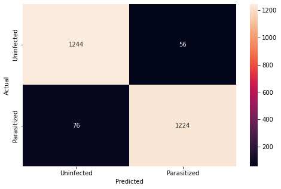

```python
prediction_report(model,test_images)
```

**Plotting the train and validation curves**

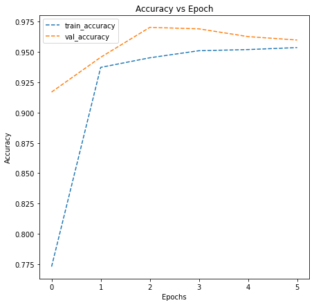

```python
plot_accuracy(history)
```

#### **Notes on CNN0:**

The base model CNN0 consists of 3 convolution+maxpool layers followed by a single dense (fully-connected) layer. This is already a very good model for the following reasons:

- It has 95% accuracy on the test data (woth accuracy chosen here as the scoring metric).
- It also has great precision, recall and other metrics for binary classification (aroun 95%).
- It doesnt seem overfitted, as seen by accuracy converging with epochs to similar values on the training and validation datasets.

#### **Analysis of CNN0 Model Errors**

In this section we look at model errors from CNN0. Misclassification is rare (5%) so we focus on these cases to understand the reasons and seek potential improvements.

```python
# Load model CNN0
from tensorflow.keras.models import load_model
model = load_model('/content/drive/MyDrive/Data/CNN0.h5')

y_pred_proba = model.predict(test_images)# predicted probability (two classes)
y_pred = np.argmax(y_pred_proba,axis = -1)# convert boolean
y_true = np.argmax(test_labels,axis = -1)

# Build database of misclassified images
misclass_images=[]
misclass_labels=[]
misclass_probas=[]# predicted probability 0-1
misclass_index=[]# save index from full database
for count,(i,j,k,l) in enumerate(zip(test_images,y_pred,y_true,y_pred_proba)):
  if j != k:
    misclass_images.append(i)# image
    misclass_labels.append(k)# truth
    misclass_probas.append(l[0])# predicted probability
    misclass_index.append(count)# save index from database

# Sort by increasing probability (one liner!)
misclass_probas,misclass_labels,misclass_images = map(list, zip(*sorted(zip(misclass_probas,misclass_labels,misclass_images), reverse=True)))
```

```
132
```

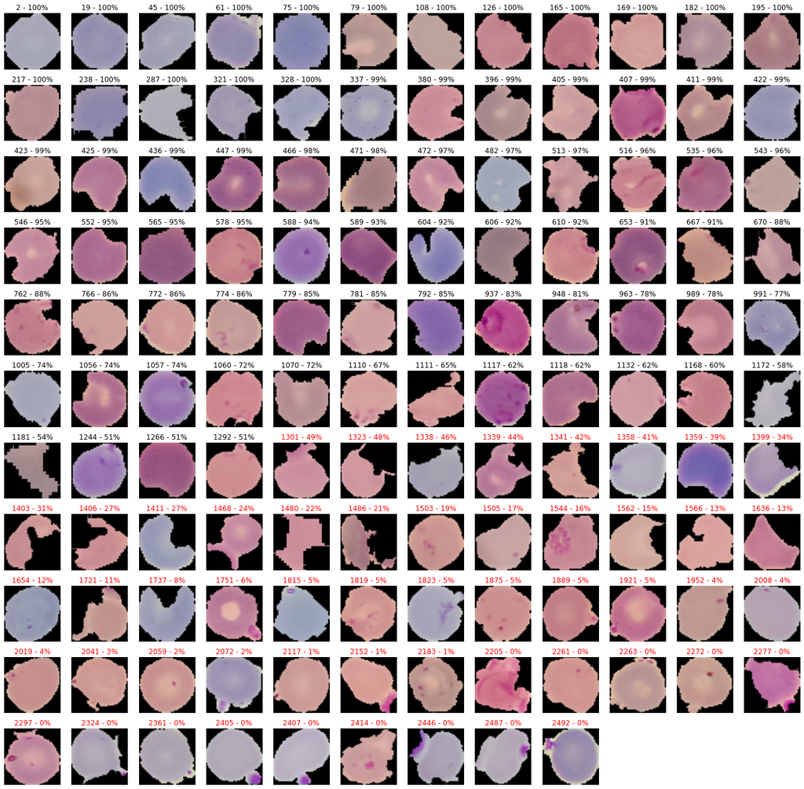

```python
# Visualize all the misclassified from CNN0:
print(len(misclass_probas))# there are 129 misclassified images
np.random.seed()
plt.figure(1 , figsize = (24 , 24))

for n in range(0, 129):
    plt.subplot(11, 12, n+1)
    index=n# just follow
    # index = int(np.random.randint(0, len(misclass_probas), 1))# any
    # index = int(np.random.randint(0, len(misclass_probas)/4, 1))# first quartile
    # index = int(np.random.randint(3*len(misclass_probas)/4, len(misclass_probas), 1))# last quartile
    plt.imshow(misclass_images[index])
    if misclass_labels[index] == 1:# uninfected
      plt.title(str(misclass_index[index])+' - '+str(round(misclass_probas[index]*100))+'%')
    else:
      plt.title(str(misclass_index[index])+' - '+str(round(misclass_probas[index]*100))+'%',color='r')

    plt.axis('off')
```

**Notes on misclassified images:**

- The misclassified uninfected (with predicted proba around 100%) cells have either disformed shapes, or a very small light center (that might be confused for a malaria parasite)
- The misclassified parasitized cells (with predicted proba around 0%) may have a very small malaria parasite, or a malaria parasite that is cropped or a the cell edge.
- The cells with predicted proba around 50% have very disformed shapes that are likely to be outliers in the database.

### **Model 1 (CNN1)**

#### **Trying to improve the performance of our model by adding new layers**

Let's try to build another model with few more layers and try to check if we can try to improve the model. Therefore try to build a model by adding few layers if required and altering the activation functions.

Lets try a simple improvement by adding a dense layer (512 weights) to the CNN0. This is the simplest We refer to this new model as CNN1.

```python
#Clearing backend
from tensorflow.keras import backend
from tensorflow.keras.utils import to_categorical
from tensorflow.keras.models import Sequential
from tensorflow.keras.layers import Conv2D,MaxPooling2D,Dense,Flatten,Dropout
from tensorflow.keras.callbacks import EarlyStopping, ModelCheckpoint
from random import shuffle

backend.clear_session()
#Fixing the seed for random number generators so that we can ensure we receive the same output everytime
np.random.seed(42)
import random
random.seed(42)
tf.random.set_seed(42)
```

#### **Building the Model**

```python
#creating sequential model
model1=Sequential()
model1.add(Conv2D(filters=32,kernel_size=2,padding="same",activation="relu",input_shape=(64,64,3)))
model1.add(MaxPooling2D(pool_size=2))
model1.add(Dropout(0.2))
model1.add(Conv2D(filters=32,kernel_size=2,padding="same",activation="relu"))
model1.add(MaxPooling2D(pool_size=2))
model1.add(Dropout(0.2))
model1.add(Conv2D(filters=32,kernel_size=2,padding="same",activation="relu"))
model1.add(MaxPooling2D(pool_size=2))
model1.add(Dropout(0.2))
model1.add(Flatten())
model1.add(Dense(512,activation="relu"))
model1.add(Dropout(0.4))
model1.add(Dense(512,activation="relu"))# we add a second dense layer of same size
model1.add(Dropout(0.4))
model1.add(Dense(2,activation="softmax"))
model1.summary()
```

```
Model: "sequential"
_________________________________________________________________
Layer (type)                 Output Shape              Param #
=================================================================
conv2d (Conv2D)              (None, 64, 64, 32)        416
_________________________________________________________________
max_pooling2d (MaxPooling2D) (None, 32, 32, 32)        0
_________________________________________________________________
dropout (Dropout)            (None, 32, 32, 32)        0
_________________________________________________________________
conv2d_1 (Conv2D)            (None, 32, 32, 32)        4128
_________________________________________________________________
max_pooling2d_1 (MaxPooling2 (None, 16, 16, 32)        0
_________________________________________________________________
dropout_1 (Dropout)          (None, 16, 16, 32)        0
_________________________________________________________________
conv2d_2 (Conv2D)            (None, 16, 16, 32)        4128
_________________________________________________________________
max_pooling2d_2 (MaxPooling2 (None, 8, 8, 32)          0
_________________________________________________________________
dropout_2 (Dropout)          (None, 8, 8, 32)          0
_________________________________________________________________
flatten (Flatten)            (None, 2048)              0
_________________________________________________________________
dense (Dense)                (None, 512)               1049088
_________________________________________________________________
dropout_3 (Dropout)          (None, 512)               0
_________________________________________________________________
dense_1 (Dense)              (None, 512)               262656
_________________________________________________________________
dropout_4 (Dropout)          (None, 512)               0
_________________________________________________________________
dense_2 (Dense)              (None, 2)                 1026
=================================================================
Total params: 1,321,442
Trainable params: 1,321,442
Non-trainable params: 0
_________________________________________________________________
```

#### **Compiling the model**

```python
model1.compile(loss='binary_crossentropy', optimizer='adam', metrics=['accuracy'])
```

**Using Callbacks**

```python
callbacks = [EarlyStopping(monitor='val_loss', patience=2),
             ModelCheckpoint('.mdl_wts.hdf5', monitor='val_loss', save_best_only=True)]
```

**Fit and Train the model**

```python
history1=model1.fit(train_images,train_labels,batch_size=32,callbacks=callbacks,validation_split=0.2,epochs=20,verbose=1)
```

```python
# save the model
model1.save('/content/drive/MyDrive/Data/CNN1.h5')
```

#### **Evaluating the model**

```python
accuracy1 = model1.evaluate(test_images, test_labels, verbose=1)
print('\n', 'Test_Accuracy:-', accuracy1[1])
```

```
 Test_Accuracy:- 0.9515384435653687
```

**Plotting the confusion matrix**

```
              precision    recall  f1-score   support

           0       0.95      0.95      0.95      1300
           1       0.95      0.95      0.95      1300

    accuracy                           0.95      2600
   macro avg       0.95      0.95      0.95      2600
weighted avg       0.95      0.95      0.95      2600
```

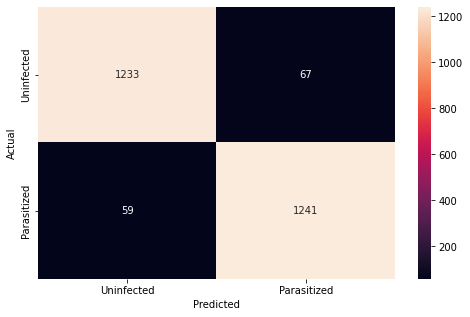

```python
prediction_report(model1,test_images)
```

**Plotting the Train and validation curves**

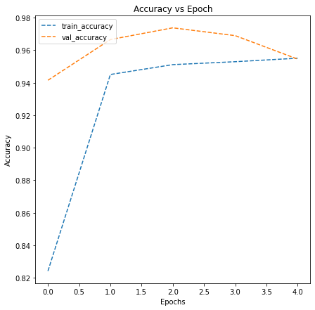

```python
plot_accuracy(history1)
```

#### **Notes on CNN1**:

The model CNN1 is the CNN0 with an additional dense (fully-connected layer) of 512 weights:

- It doesnt really improve accuracy (95%) or other metrics compared to CNN0.
- This suggests that the additional dense layer is unecessary (at least at this stage of exploration).

### **Model CNN2 with Leaky Relu and Batch Normalization**

- Can the model performance be improved if we change our activation function to LeakyRelu?
- Can BatchNormalization improve our model? It is usually used to speed up convergence, and also regularizes the model as a side-effect.

**Notes:**

- LeakyRelu replaces Relu for all activation function except the final binary classification (that is always sigmoid/softmax)
- It is advised against using Batch Normalization and Dropout altogether (due to noisy statistics used to normalize), cf Deep Learning 2016 p 425.

```python
#Clearing backend
from tensorflow.keras import backend
backend.clear_session()

#Fixing the seed for random number generators
np.random.seed(42)
import random
random.seed(42)
tf.random.set_seed(42)
```

#### **Building the Model**

```python
model2 = Sequential()
model2.add(Conv2D(32, (3,3), input_shape=(64, 64, 3), padding='same'))
model2=Sequential()
model2.add(Conv2D(filters=32,kernel_size=2,padding="same",activation=LeakyReLU(),input_shape=(64,64,3)))
model2.add(BatchNormalization())# Add batch normalization after convolution
model2.add(MaxPooling2D(pool_size=2))
model2.add(Dropout(0.2))
model2.add(Conv2D(filters=32,kernel_size=2,padding="same",activation=LeakyReLU()))
model.add(BatchNormalization())# Add batch normalization after convolution
model2.add(MaxPooling2D(pool_size=2))
model2.add(Dropout(0.2))
model2.add(Conv2D(filters=32,kernel_size=2,padding="same",activation=LeakyReLU()))
model2.add(BatchNormalization())# Add batch normalization after convolution
model2.add(MaxPooling2D(pool_size=2))
model2.add(Dropout(0.2))
model2.add(Flatten())
model2.add(Dense(512,activation=LeakyReLU()))
model2.add(Dropout(0.4))
model2.add(BatchNormalization())# Add batch normalization after dense (and dropout)
model2.add(Dense(2,activation="softmax"))#always sigmoid for binary classification
model2.summary()
```

```
Model: "sequential_1"
_________________________________________________________________
Layer (type)                 Output Shape              Param #
=================================================================
conv2d_1 (Conv2D)            (None, 64, 64, 32)        416
_________________________________________________________________
batch_normalization (BatchNo (None, 64, 64, 32)        128
_________________________________________________________________
max_pooling2d (MaxPooling2D) (None, 32, 32, 32)        0
_________________________________________________________________
dropout (Dropout)            (None, 32, 32, 32)        0
_________________________________________________________________
conv2d_2 (Conv2D)            (None, 32, 32, 32)        4128
_________________________________________________________________
max_pooling2d_1 (MaxPooling2 (None, 16, 16, 32)        0
_________________________________________________________________
dropout_1 (Dropout)          (None, 16, 16, 32)        0
_________________________________________________________________
conv2d_3 (Conv2D)            (None, 16, 16, 32)        4128
_________________________________________________________________
batch_normalization_2 (Batch (None, 16, 16, 32)        128
_________________________________________________________________
max_pooling2d_2 (MaxPooling2 (None, 8, 8, 32)          0
_________________________________________________________________
dropout_2 (Dropout)          (None, 8, 8, 32)          0
_________________________________________________________________
flatten (Flatten)            (None, 2048)              0
_________________________________________________________________
dense (Dense)                (None, 512)               1049088
_________________________________________________________________
dropout_3 (Dropout)          (None, 512)               0
_________________________________________________________________
batch_normalization_3 (Batch (None, 512)               2048
_________________________________________________________________
dense_1 (Dense)              (None, 2)                 1026
=================================================================
Total params: 1,061,090
Trainable params: 1,059,938
Non-trainable params: 1,152
_________________________________________________________________
```

#### **Compiling the model**

```python
adam = optimizers.Adam(learning_rate=0.001)
model2.compile(loss="binary_crossentropy", optimizer=adam, metrics = ['accuracy'])
```

**Using callbacks**

```python
callbacks = [EarlyStopping(monitor='val_loss', patience=2),
             ModelCheckpoint('.mdl_wts.hdf5', monitor='val_loss', save_best_only=True)]
```

**Fit and train the model**

```python
history2 = model2.fit(train_images,train_labels,batch_size=32,callbacks=callbacks,validation_split=0.2,epochs=20,verbose=1)
```

```python
# save the model
model2.save('/content/drive/MyDrive/Data/CNN2.h5')
```

**Plotting the train and validation accuracy**

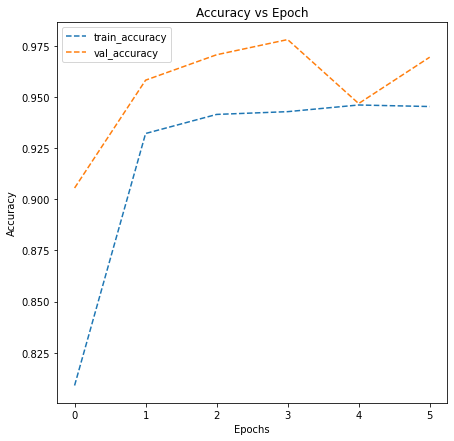

```python
# plotting the accuracies
plot_accuracy(history2)
```

#### **Evaluating the model**

```python
# Evaluate the model to calculate the accuracy
accuracy = model2.evaluate(test_images, test_labels, verbose=1)
print('\n', 'Test_Accuracy:-', accuracy[1])
```

```
 Test_Accuracy:- 0.9438461661338806
```

**Generate the classification report and confusion matrix**

```
              precision    recall  f1-score   support

           0       0.92      0.97      0.95      1300
           1       0.97      0.92      0.94      1300

    accuracy                           0.94      2600
   macro avg       0.94      0.94      0.94      2600
weighted avg       0.94      0.94      0.94      2600
```

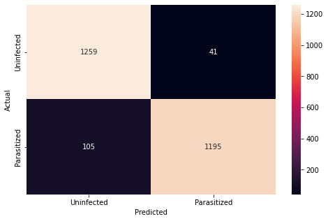

```python
prediction_report(model2,test_images)
```

### **Model CNN3 with Data Augmentation**

Lets build a model CNN3 with Data Augmentation. Can it improve the model performances? References to image data augmentation can be seen below:

- [Image Augmentation for Computer Vision](https://www.mygreatlearning.com/blog/understanding-data-augmentation/)
- [How to Configure Image Data Augmentation in Keras?](https://machinelearningmastery.com/how-to-configure-image-data-augmentation-when-training-deep-learning-neural-networks/)

```python
#Clearing backend
from tensorflow.keras import backend
backend.clear_session()
#Fixing the seed for random number generators
np.random.seed(42)
import random
random.seed(42)
tf.random.set_seed(42)
```

#### **Using image data generator**

```python
from sklearn.model_selection import train_test_split
X_train, X_val, y_train, y_val = train_test_split(train_images, train_labels, train_size=0.2, random_state=42)
from tensorflow.keras.preprocessing.image import ImageDataGenerator

# Using ImageDataGenerator to generate images

train_datagen = ImageDataGenerator(horizontal_flip=True,
                                  zoom_range = 0.5, rotation_range=30)
val_datagen  = ImageDataGenerator()# no transformations on validation dataset

# Flowing training images using train_datagen generator
train_generator = train_datagen.flow(x = X_train, y = y_train, batch_size=64, seed=42, shuffle=True)

# Flowing validation images using val_datagen generator
val_generator =  val_datagen.flow(x= X_val, y = y_val, batch_size=64, seed=42, shuffle=True)
```

#### **Visualizing Augmented images**

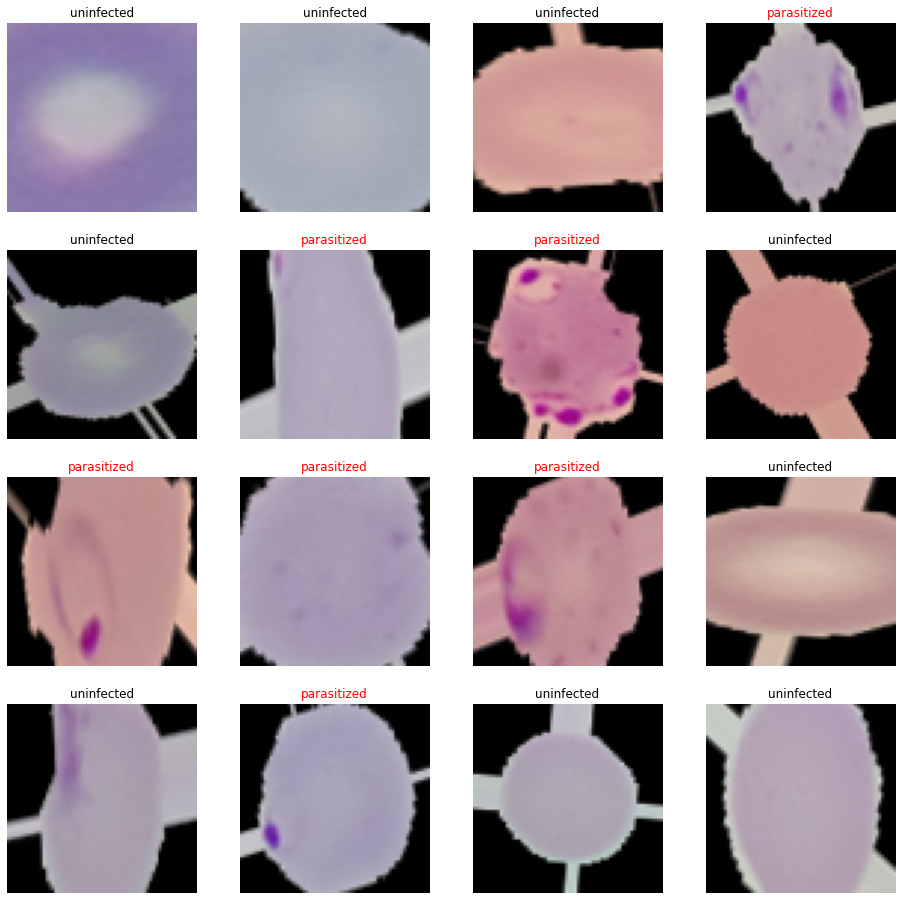

```python
#Creating an iterable for images and labels from the training data
images, labels = next(train_generator)

#Plotting 16 images from the training data
fig, axes = plt.subplots(4, 4, figsize = (16, 8))
fig.set_size_inches(16, 16)
for (image, label, ax) in zip(images, labels, axes.flatten()):
    ax.imshow(image)
    if label[1] == 1:# Remember we have one-hot-encoded label (to uninfected=[1,0],parasitized=[1,0])
        ax.set_title('parasitized',color='r')
    elif label[0] == 1:
        ax.set_title('uninfected')
    else:
        ax.set_title('label error')
    ax.axis('off')
```

**Observations and insights:** Data Augmentation has a great potential because there are very natural invariances in the database of red cell images. In fact, each red cell is arbitrarily framed to fit perfectly in a squared surface:

- Rotations of +90, +180, +270 can naturally occur depending on the random orientation of the red cell during framing.
- Similarly, a horizontal flip (or redundant vertical flip) can naturally occur if the red cell is flipped within the thin blood smear.
- However, rotations with arbitrary angles doesnt respect the framing and is likely unecessary.
- The zoom transformation however seems inadequate here, because it doesnt respect the framing. The resulting images are too different from the ones of the original database. For example, a reduced zoom results in spurious strides.
- Other transformations may be useful as well such as changing brightness and adding noise.

#### **Building the Model**

```python
#creating sequential model (same as CNN0)
model3=Sequential()
model3.add(Conv2D(filters=32,kernel_size=2,padding="same",activation="relu",input_shape=(64,64,3)))
model3.add(MaxPooling2D(pool_size=2))
model3.add(Dropout(0.2))
model3.add(Conv2D(filters=32,kernel_size=2,padding="same",activation="relu"))
model3.add(MaxPooling2D(pool_size=2))
model3.add(Dropout(0.2))
model3.add(Conv2D(filters=32,kernel_size=2,padding="same",activation="relu"))
model3.add(MaxPooling2D(pool_size=2))
model3.add(Dropout(0.2))
model3.add(Flatten())
model3.add(Dense(512,activation="relu"))
model3.add(Dropout(0.4))
model3.add(Dense(2,activation="softmax"))#2 represent output layer neurons
model3.summary()
```

```
Model: "sequential"
_________________________________________________________________
Layer (type)                 Output Shape              Param #
=================================================================
conv2d (Conv2D)              (None, 64, 64, 32)        416
_________________________________________________________________
max_pooling2d (MaxPooling2D) (None, 32, 32, 32)        0
_________________________________________________________________
dropout (Dropout)            (None, 32, 32, 32)        0
_________________________________________________________________
conv2d_1 (Conv2D)            (None, 32, 32, 32)        4128
_________________________________________________________________
max_pooling2d_1 (MaxPooling2 (None, 16, 16, 32)        0
_________________________________________________________________
dropout_1 (Dropout)          (None, 16, 16, 32)        0
_________________________________________________________________
conv2d_2 (Conv2D)            (None, 16, 16, 32)        4128
_________________________________________________________________
max_pooling2d_2 (MaxPooling2 (None, 8, 8, 32)          0
_________________________________________________________________
dropout_2 (Dropout)          (None, 8, 8, 32)          0
_________________________________________________________________
flatten (Flatten)            (None, 2048)              0
_________________________________________________________________
dense (Dense)                (None, 512)               1049088
_________________________________________________________________
dropout_3 (Dropout)          (None, 512)               0
_________________________________________________________________
dense_1 (Dense)              (None, 2)                 1026
=================================================================
Total params: 1,058,786
Trainable params: 1,058,786
Non-trainable params: 0
_________________________________________________________________
```

```python
# compile
adam = optimizers.Adam(learning_rate=0.001)
model3.compile(loss='binary_crossentropy', optimizer='adam', metrics=['accuracy'])
```

**Using Callbacks**

```python
callbacks = [EarlyStopping(monitor='val_loss', patience=2),
             ModelCheckpoint('.mdl_wts.hdf5', monitor='val_loss', save_best_only=True)]
```

**Fit and Train the model**

```python
history3 = model3.fit(train_generator,
                                  validation_data=val_generator,
                                  batch_size=32,callbacks=callbacks,
                                  epochs=20,verbose=1)
```

```python
# (model not saved, save CNN3b instead)
```

#### **Evaluating the model**

**Plot the train and validation accuracy**

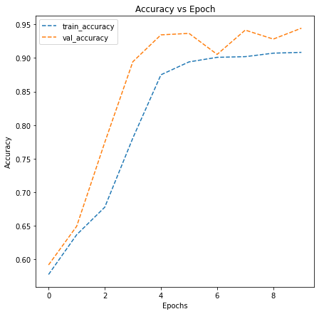

```python
# plotting the accuracies
plot_accuracy(history3)
```

```python
# Evaluating the model on test data
accuracy3 = model3.evaluate(test_images, test_labels, verbose=1)
print('\n', 'Test_Accuracy:-', accuracy3[1])
```

```
 Test_Accuracy:- 0.9430769085884094
```

**Plotting the classification report and confusion matrix**

```
              precision    recall  f1-score   support

           0       0.92      0.96      0.94      1300
           1       0.96      0.92      0.94      1300

    accuracy                           0.94      2600
   macro avg       0.94      0.94      0.94      2600
weighted avg       0.94      0.94      0.94      2600
```

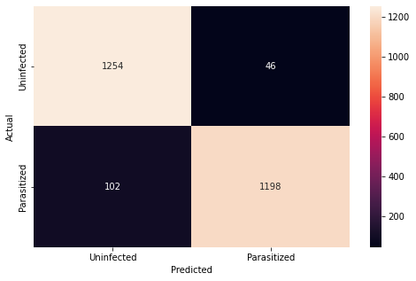

```python
prediction_report(model3,test_images)
```

### **Model with Data Augmentation CNN4**

Let us try a different range of data augmentation on model CNN4. We will only apply rotation (within 360 degrees range) and flip.

```python
from sklearn.model_selection import train_test_split
X_train, X_val, y_train, y_val = train_test_split(train_images, train_labels, train_size=0.2, random_state=42)
from tensorflow.keras.preprocessing.image import ImageDataGenerator

# Using ImageDataGenerator to generate images

train_datagen = ImageDataGenerator(horizontal_flip=True, rotation_range=360)
val_datagen  = ImageDataGenerator()# no transformations on validation dataset

# Flowing training images using train_datagen generator
train_generator = train_datagen.flow(x = X_train, y = y_train, batch_size=64, seed=42, shuffle=True)

# Flowing validation images using val_datagen generator
val_generator =  val_datagen.flow(x= X_val, y = y_val, batch_size=64, seed=42, shuffle=True)
```

```python
# lets retrain the same model on new augmented data
history3 = model3.fit(train_generator,
                                  validation_data=val_generator,
                                  batch_size=32,callbacks=callbacks,
                                  epochs=20,verbose=1)
```

```python
# save the model
model3.save('/content/drive/MyDrive/Data/CNN3b.h5')
```

```
None
```

```
 Test_Accuracy:- 0.9419230818748474
              precision    recall  f1-score   support

           0       0.93      0.96      0.94      1300
           1       0.96      0.92      0.94      1300

    accuracy                           0.94      2600
   macro avg       0.94      0.94      0.94      2600
weighted avg       0.94      0.94      0.94      2600
```

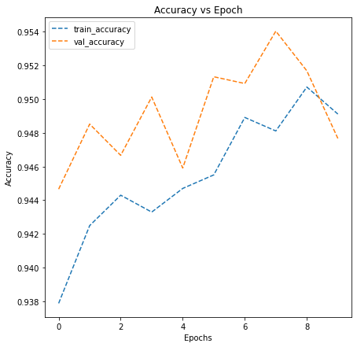

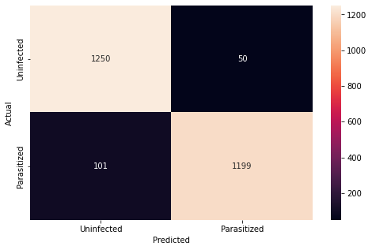

```python
# Analysis for CNN3b
display(plot_accuracy(history3))
accuracy3 = model3.evaluate(test_images, test_labels, verbose=1)
print('\n', 'Test_Accuracy:-', accuracy3[1])
prediction_report(model3,test_images)
```

### **Pre-trained model (VGG16)**

Now let us try to use a pretrained model like VGG16 and check how it performs on our data.

```python
#Clearing backend
from tensorflow.keras import backend
backend.clear_session()
#Fixing the seed for random number generators
np.random.seed(42)
import random
random.seed(42)
tf.random.set_seed(42)
```

```python
from tensorflow.keras.applications.vgg16 import VGG16
from tensorflow.keras import Model

vgg = VGG16(include_top=False, weights='imagenet', input_shape=(64,64,3))# do not include dense layers at top of network
vgg.summary()
```

```
Downloading data from https://storage.googleapis.com/tensorflow/keras-applications/vgg16/vgg16_weights_tf_dim_ordering_tf_kernels_notop.h5
Model: "vgg16"
_________________________________________________________________
Layer (type)                 Output Shape              Param #
=================================================================
input_1 (InputLayer)         [(None, 64, 64, 3)]       0
_________________________________________________________________
block1_conv1 (Conv2D)        (None, 64, 64, 64)        1792
_________________________________________________________________
block1_conv2 (Conv2D)        (None, 64, 64, 64)        36928
_________________________________________________________________
block1_pool (MaxPooling2D)   (None, 32, 32, 64)        0
_________________________________________________________________
block2_conv1 (Conv2D)        (None, 32, 32, 128)       73856
_________________________________________________________________
block2_conv2 (Conv2D)        (None, 32, 32, 128)       147584
_________________________________________________________________
block2_pool (MaxPooling2D)   (None, 16, 16, 128)       0
_________________________________________________________________
block3_conv1 (Conv2D)        (None, 16, 16, 256)       295168
_________________________________________________________________
block3_conv2 (Conv2D)        (None, 16, 16, 256)       590080
_________________________________________________________________
block3_conv3 (Conv2D)        (None, 16, 16, 256)       590080
_________________________________________________________________
block3_pool (MaxPooling2D)   (None, 8, 8, 256)         0
_________________________________________________________________
block4_conv1 (Conv2D)        (None, 8, 8, 512)         1180160
_________________________________________________________________
block4_conv2 (Conv2D)        (None, 8, 8, 512)         2359808
_________________________________________________________________
block4_conv3 (Conv2D)        (None, 8, 8, 512)         2359808
_________________________________________________________________
block4_pool (MaxPooling2D)   (None, 4, 4, 512)         0
_________________________________________________________________
block5_conv1 (Conv2D)        (None, 4, 4, 512)         2359808
_________________________________________________________________
block5_conv2 (Conv2D)        (None, 4, 4, 512)         2359808
_________________________________________________________________
block5_conv3 (Conv2D)        (None, 4, 4, 512)         2359808
_________________________________________________________________
block5_pool (MaxPooling2D)   (None, 2, 2, 512)         0
=================================================================
Total params: 14,714,688
Trainable params: 14,714,688
Non-trainable params: 0
_________________________________________________________________
```

```python
# Fix the bottom layers of the VGG16 (cant train)
transfer_layer = vgg.get_layer('block5_pool')
vgg.trainable=False

# Setup the top layers of the VGG16
x = Flatten()(transfer_layer.output) #Flatten the output from the 3rd block of the VGG16 model
x = Dense(256, activation='relu')(x)
x = Dense(128, activation='relu')(x)
x = Dropout(0.3)(x)
x = Dense(64, activation='relu')(x)
x = BatchNormalization()(x)
pred = Dense(2, activation='softmax')(x)# final classification layer

# Combine bottom (fixed) and top layers
model4 = Model(vgg.input, pred)
```

#### **Compiling the model**

```python
# Compiling the model
model4.compile(loss='binary_crossentropy', optimizer='adam', metrics=['accuracy'])
```

**using callbacks**

```python
# Adding Callbacks to the model
callbacks = [EarlyStopping(monitor='val_loss', patience=2),
             ModelCheckpoint('.mdl_wts.hdf5', monitor='val_loss', save_best_only=True)]
```

**Fit and Train the model**

```python
#Fitting the model and running the model for 10 epochs
history4=model4.fit(train_images,train_labels,batch_size=32,callbacks=callbacks,validation_split=0.2,epochs=10,verbose=1)
```

```python
# save the model
model4.save('/content/drive/MyDrive/Data/VGG16.h5')
# del model4
#from keras.models import load_model
#model4=load_model('/content/drive/MyDrive/Data/VGG16.h5')
```

#### **Evaluating the model**

```
None
```

```
 Test_Accuracy:- 0.9223076701164246
              precision    recall  f1-score   support

           0       0.96      0.88      0.92      1300
           1       0.89      0.96      0.93      1300

    accuracy                           0.92      2600
   macro avg       0.93      0.92      0.92      2600
weighted avg       0.93      0.92      0.92      2600
```

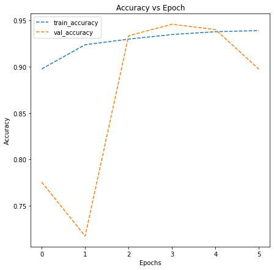

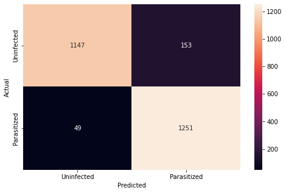

```python
# Analysis for VGG16
display(plot_accuracy(history4))
accuracy = model4.evaluate(test_images, test_labels, verbose=1)
print('\n', 'Test_Accuracy:-', accuracy[1])
prediction_report(model4,test_images)
```

#### **Notes on VGG16**

The VGG16 model uses transfer learning, we download and fix the bottom convolution layers and train 3 fully connected layers on top of it.

```python
# Load model CNN0
from tensorflow.keras.models import load_model
model = load_model('/content/drive/MyDrive/Data/CNN0.h5')

y_pred_proba = model.predict(test_images)# predicted probability (two classes)
y_pred = np.argmax(y_pred_proba,axis = -1)# convert boolean
y_true = np.argmax(test_labels,axis = -1)

# Build database of misclassified images
misclass_images=[]
misclass_labels=[]
misclass_probas=[]# predicted probability 0-1
misclass_index=[]# save index from full database
for count,(i,j,k,l) in enumerate(zip(test_images,y_pred,y_true,y_pred_proba)):
  if j != k:
    misclass_images.append(i)# image
    misclass_labels.append(k)# truth
    misclass_probas.append(l[0])# predicted probability
    misclass_index.append(count)# save index from database

# Sort by increasing probability (one liner!)
misclass_probas,misclass_labels,misclass_images = map(list, zip(*sorted(zip(misclass_probas,misclass_labels,misclass_images), reverse=True)))
```

### **Model CNN5**

We build a model CNN5. As compared to CNN0 it uses more convolution layers (increasing progressively in size), and more dense layers (i.e. increase in depth).

```python
import tensorflow as tf
from keras import layers
from keras.layers import Dropout , Input, Add, Dense, Activation, ZeroPadding2D, BatchNormalization, Flatten, Conv2D, AveragePooling2D, MaxPooling2D, GlobalMaxPooling2D
from keras.models import Model, load_model
from keras.initializers import glorot_uniform

# Model CNN5 buildup
inp = Input(shape = (64 , 64 , 3))
x = Conv2D(filters = 16 , kernel_size = (3,3) , strides = (1,1) , padding = "same" , kernel_initializer=glorot_uniform(seed = 2))(inp)
x = Activation("relu")(x)
x = Dropout(0.2)(x)
x = Conv2D(filters = 32 , kernel_size = (4,4) , strides = (2,2) , padding = "same" , kernel_initializer=glorot_uniform(seed = 2))(x)
x = Activation("relu")(x)
x = MaxPooling2D(pool_size = (2,2) , strides = (2,2) , padding = "same")(x)
x = Dropout(0.2)(x)
x = Conv2D(filters = 64 , kernel_size = (3,3) , strides = (2,2) , padding = "same" , kernel_initializer = glorot_uniform(seed = 2))(x)
x = Activation("relu")(x)
x = Dropout(0.2)(x)
x = Conv2D(filters = 128 , kernel_size = (3,3) , strides = (1,1) , padding = "same" , kernel_initializer = glorot_uniform())(x)
x = Activation("relu")(x)
x = MaxPooling2D(pool_size = (2,2) , strides = (2,2) , padding = "same")(x)
x = Dropout(0.2)(x)
x = Conv2D(filters = 256 , kernel_size = (2,2) , strides = (2,2) , padding = "same" , kernel_initializer = glorot_uniform())(x)
x = Activation("relu")(x)
x = AveragePooling2D(pool_size = (3,3) , strides = (1,1) , padding = "same")(x)
x = Dropout(0.2)(x)
x = Flatten()(x)
x = Dense(128)(x)
x = Activation("relu")(x)
x = Dropout(0.2)(x)
x = Dense(64)(x)
x = Activation("relu")(x)
x = Dropout(0.2)(x)
x = Dense(32)(x)
x = Activation("relu")(x)
x = Dropout(0.2)(x)
x = Dense(2)(x)
output = Activation("softmax")(x)
model5  = Model(inputs =inp , outputs = output )
model5.summary()
```

```
Model: "model_6"
_________________________________________________________________
Layer (type)                 Output Shape              Param #
=================================================================
input_8 (InputLayer)         [(None, 64, 64, 3)]       0
_________________________________________________________________
conv2d_35 (Conv2D)           (None, 64, 64, 16)        448
_________________________________________________________________
activation_59 (Activation)   (None, 64, 64, 16)        0
_________________________________________________________________
dropout_52 (Dropout)         (None, 64, 64, 16)        0
_________________________________________________________________
conv2d_36 (Conv2D)           (None, 32, 32, 32)        8224
_________________________________________________________________
activation_60 (Activation)   (None, 32, 32, 32)        0
_________________________________________________________________
max_pooling2d_14 (MaxPooling (None, 16, 16, 32)        0
_________________________________________________________________
dropout_53 (Dropout)         (None, 16, 16, 32)        0
_________________________________________________________________
conv2d_37 (Conv2D)           (None, 8, 8, 64)          18496
_________________________________________________________________
activation_61 (Activation)   (None, 8, 8, 64)          0
_________________________________________________________________
dropout_54 (Dropout)         (None, 8, 8, 64)          0
_________________________________________________________________
conv2d_38 (Conv2D)           (None, 8, 8, 128)         73856
_________________________________________________________________
activation_62 (Activation)   (None, 8, 8, 128)         0
_________________________________________________________________
max_pooling2d_15 (MaxPooling (None, 4, 4, 128)         0
_________________________________________________________________
dropout_55 (Dropout)         (None, 4, 4, 128)         0
_________________________________________________________________
conv2d_39 (Conv2D)           (None, 2, 2, 256)         131328
_________________________________________________________________
activation_63 (Activation)   (None, 2, 2, 256)         0
_________________________________________________________________
average_pooling2d_7 (Average (None, 2, 2, 256)         0
_________________________________________________________________
```

[output cut: 15 more lines]

```
_________________________________________________________________
dense_26 (Dense)             (None, 32)                2080
_________________________________________________________________
activation_66 (Activation)   (None, 32)                0
_________________________________________________________________
dropout_59 (Dropout)         (None, 32)                0
_________________________________________________________________
dense_27 (Dense)             (None, 2)                 66
_________________________________________________________________
activation_67 (Activation)   (None, 2)                 0
=================================================================
Total params: 373,954
Trainable params: 373,954
Non-trainable params: 0
_________________________________________________________________
```

```python
model5.compile(loss='binary_crossentropy', optimizer='adam', metrics=['accuracy'])
callbacks = [EarlyStopping(monitor='val_loss', patience=2),
             ModelCheckpoint('.mdl_wts.hdf5', monitor='val_loss', save_best_only=True)]
```

```python
#Fit the model
history5=model5.fit(train_images,train_labels,batch_size=32,callbacks=callbacks,validation_split=0.2,epochs=20,verbose=1)
```

```python
# save the model
model5.save('/content/drive/MyDrive/Data/CNN5.h5')
```

```
None
```

```
 Test_Accuracy:- 0.9511538743972778
              precision    recall  f1-score   support

           0       0.95      0.95      0.95      1300
           1       0.95      0.95      0.95      1300

    accuracy                           0.95      2600
   macro avg       0.95      0.95      0.95      2600
weighted avg       0.95      0.95      0.95      2600
```

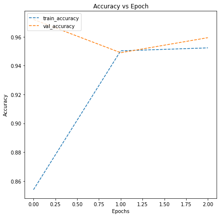

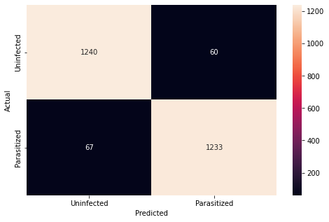

```python
display(plot_accuracy(history5))
accuracy = model5.evaluate(test_images, test_labels, verbose=1)
print('\n', 'Test_Accuracy:-', accuracy[1])
prediction_report(model5,test_images)
```

#### **Notes on CNN5:**

The CNN5 model uses a simple yet efficient architecture, and reaches around 95% accuracy like the other models.

### **Continued...**

I reached RAM and Disk limit on Google Collab, and therefore continue exploration in a second notebook.